# M7 Lab 6

Emily Shepherd

2023-02-19

# The Data:

The data displayed is from the built-in data set ChickWeight. This set included data from 50 different chicks. They were assigned one of four diets and their weight was tracked over the first 21 days of their lives. I chose this data because it included both quantitative variables and also factors.

# The Plot:

I created two facet graphs and combined them into one display using ggarrange. In the first facet graph, each subgraph provided information about the weight gain of chicks over time. The raw data was plotted for the individual chicks. From looking at this, I thought it would be beneficial to exam the boxplots for each day and separate them by diet. The second facet plot I created each subplot represented a day. Within the subplot parallel boxplots were displayed. Viewers could easily see the center and spread for each diet. Additionally, by looking over all the subplots, one can see how it changes over time.

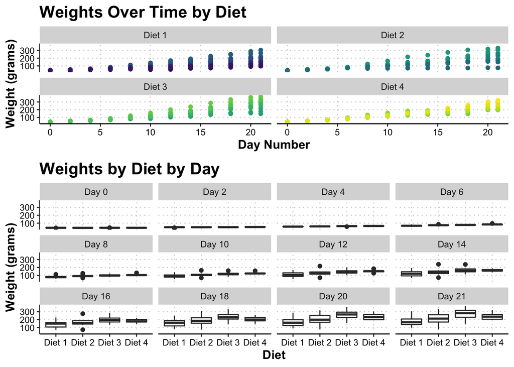